# test_hw2

Liming Ning

2022/2/6

```r
rm(list = ls())
```

# Case 2: Breast cancer sub-type

```r
cancer = fread("data/brca_subtype.csv")
patient = fread("data/brca_x_patient.csv")
```

## Summary and transformation

**Number of patients in each subtype**

```r
cancer[,.(number = length(A1BG)),by = BRCA_Subtype_PAM50]
```

```
##    BRCA_Subtype_PAM50 number
## 1:               LumA    628
## 2:               Her2     91
## 3:               LumB    233
## 4:              Basal    208
```

**Histogram by subtype**

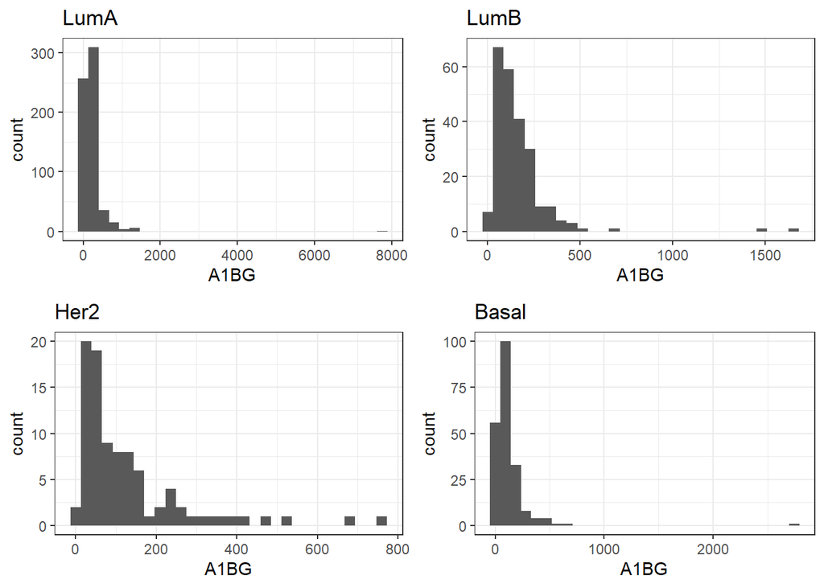

```r
hist.bysubtype = function(gene){
  luma = ggplot(data = cancer[BRCA_Subtype_PAM50 == "LumA"])+
    geom_histogram(aes(x=eval(parse(text = gene))))+
    xlab(gene)+
    labs(title = "LumA")+
    theme_bw()
  lumb = ggplot(data = cancer[BRCA_Subtype_PAM50 == "LumB"])+
    geom_histogram(aes(x=eval(parse(text = gene))))+
    xlab(gene)+
    labs(title = "LumB")+
    theme_bw()
  her2 = ggplot(data = cancer[BRCA_Subtype_PAM50 == "Her2"])+
    geom_histogram(aes(x=eval(parse(text = gene))))+
    xlab(gene)+
    labs(title = "Her2")+
    theme_bw()
  basal = ggplot(data = cancer[BRCA_Subtype_PAM50 == "Basal"])+
    geom_histogram(aes(x=eval(parse(text = gene))))+
    xlab(gene)+
    labs(title = "Basal")+
    theme_bw()
  plot_grid(luma,lumb,her2,basal,nrow = 2)
}

hist.bysubtype("A1BG")
```

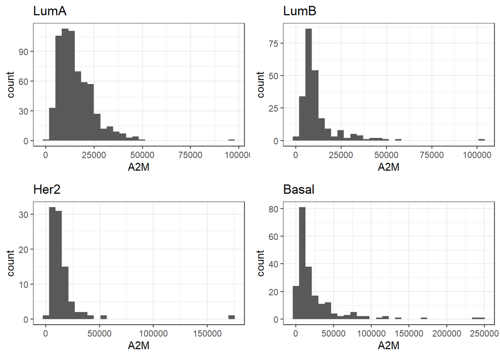

```r
hist.bysubtype("A2M")
```

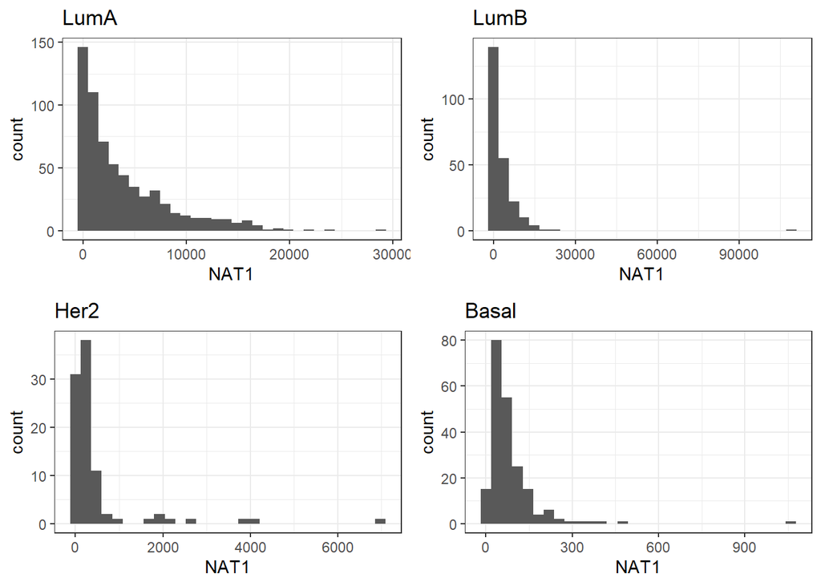

```r
hist.bysubtype("NAT1")
```

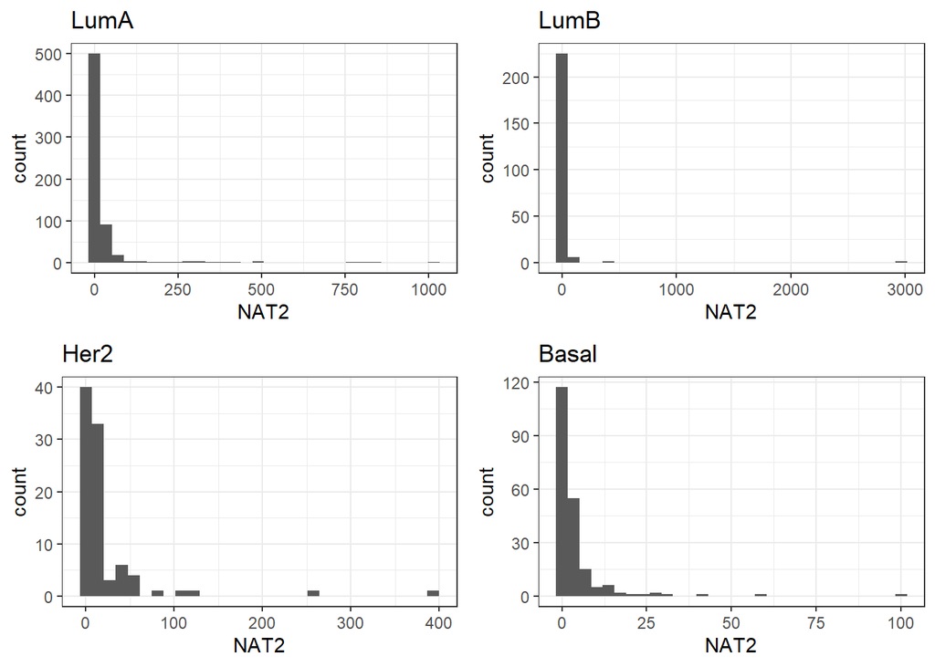

```r
hist.bysubtype("NAT2")
```

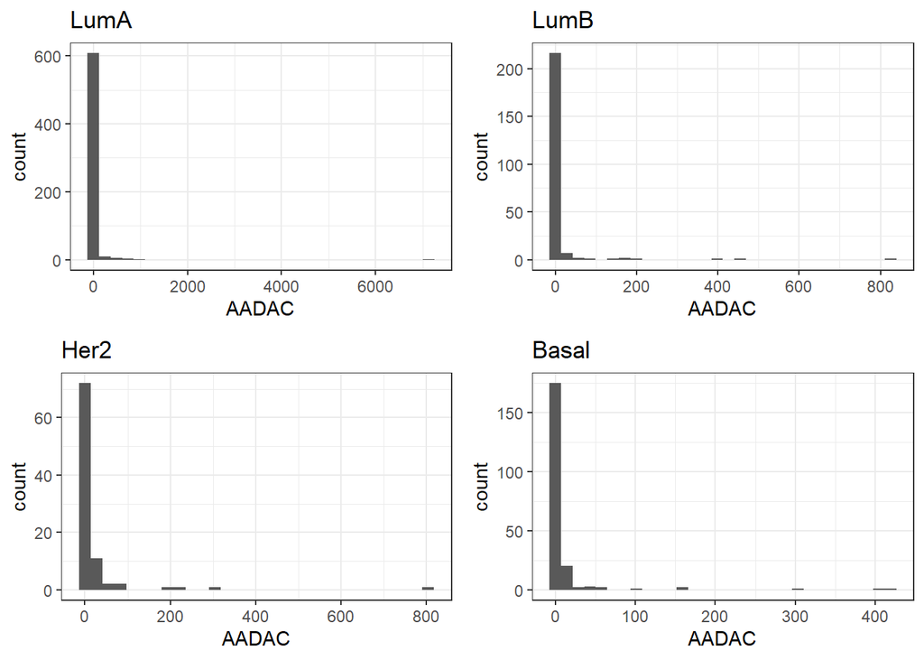

```r
hist.bysubtype("AADAC")
```

All the distributions are right-skewed. Outliers are prevalent.

**Transformation**

```r
# check NA
notna = !is.na(cancer)
notna.vec = apply(notna, 2, sum)
which(notna.vec==0)
```

```
## named integer(0)
```

```r
# check NULL
isnull.firstrow = sapply(cancer[1],is.null)
which(isnull.firstrow == T)
```

```
## named integer(0)
```

```r
# check variability
var = apply(cancer,2,var)
remove.col = which(var==0)
save(remove.col,file = "removecol.RData")
```

```r
load("removecol.RData")
```

```r
length(remove.col)
```

```
## [1] 278
```

A total of 278 genes needs to be removed due to zero variability.

```r
# remove

cancer[,(names(remove.col)) := NULL]

# deal with zeros before transforming

get.minpositive = function(vec){
  min(vec[which(vec>0)])
}
min.positiveexp = apply(cancer[,-1], 2, get.minpositive)
```

```r
for (i in 2:ncol(cancer)) {
  cancer[get(colnames(cancer)[i])==0,colnames(cancer)[i] := min.positiveexp[i-1]/2, with = F]
}
save(cancer,file = "cancer.RData")
```

```r
load("cancer.RData")
```

```r
# transforming
log.cancer = cancer[,1] %>%
  cbind(log(cancer[,-1]))
```

## kmeans clustering

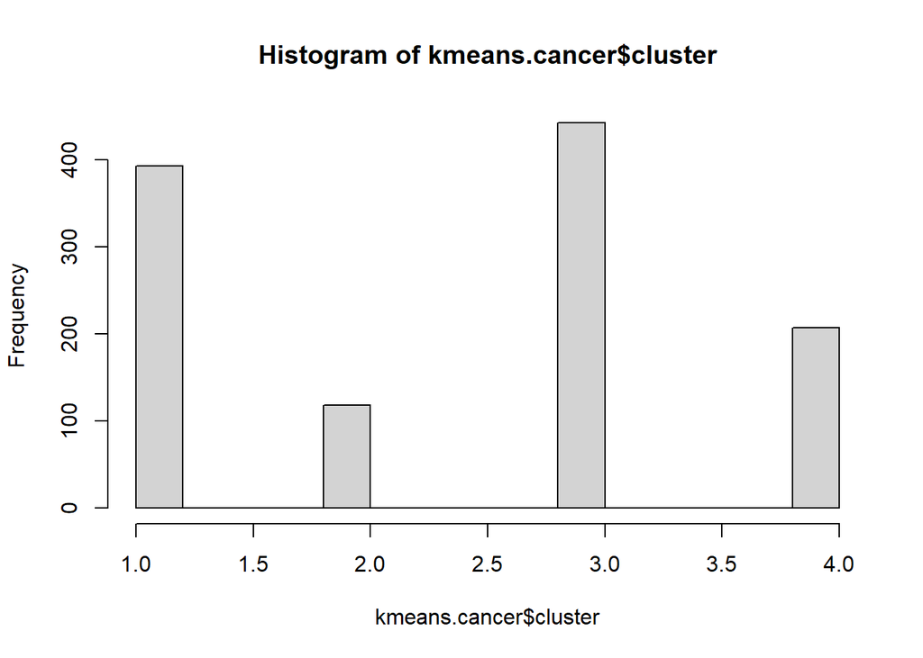

```r
set.seed(1) # otherwise the result will be different!!!
kmeans.cancer = kmeans(log.cancer[,-1],centers = 4)
hist(kmeans.cancer$cluster)
```

```r
table(log.cancer$BRCA_Subtype_PAM50,kmeans.cancer$cluster)
```

```
##
##           1   2   3   4
##   Basal   0  17   1 190
##   Her2   27   9  40  15
##   LumA  198  70 360   0
##   LumB  168  22  41   2
```

Kmeans clustering only separate Basal with others.

## Spectrum clustering

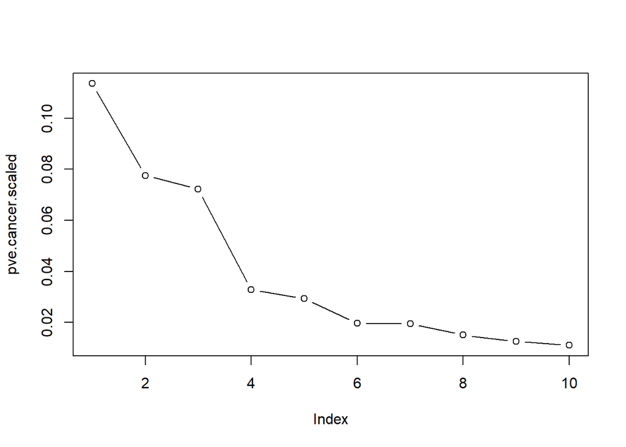

```r
log.cancer.scaled.centered = scale(log.cancer[,-1],center = T,scale = T)
svd.cancer.scaled = irlba(log.cancer.scaled.centered,nv = 10)

var.estimate.scaled = svd.cancer.scaled$d^2/(nrow(log.cancer.scaled.centered)-1)
pve.cancer.scaled = var.estimate.scaled/ncol(log.cancer.scaled.centered)
plot(pve.cancer.scaled,type = "b")
```

According to the elbow rule, we can use 3 PCs, as PVE decreases dramatically since PC4.

**Comparison of scaling choice**

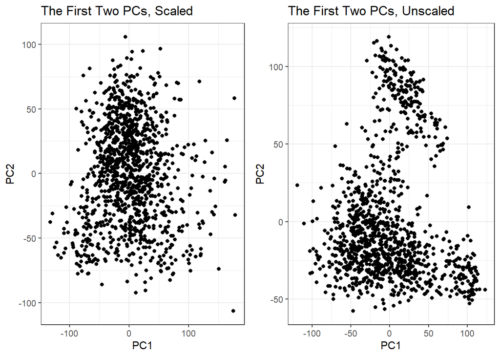

```r
pc.firsttwo.scaled = data.table(log.cancer.scaled.centered %*% svd.cancer.scaled$v[,1:2])
setnames(pc.firsttwo.scaled,c("PC1","PC2"))

log.cancer.unscaled.centered = scale(log.cancer[,-1],center = T,scale = F)
svd.cancer.unscaled = irlba(log.cancer.unscaled.centered,nv = 10)
pc.firsttwo.unscaled = data.table(log.cancer.unscaled.centered %*% svd.cancer.unscaled$v[,1:2])
setnames(pc.firsttwo.unscaled,c("PC1","PC2"))

pc.scatter.scaled = ggplot(data = pc.firsttwo.scaled,aes(x=PC1,y=PC2))+
  geom_point()+
  labs(title = "The First Two PCs, Scaled")+
  theme_bw()

pc.scatter.unscaled = ggplot(data = pc.firsttwo.unscaled,aes(x=PC1,y=PC2))+
  geom_point()+
  labs(title = "The First Two PCs, Unscaled")+
  theme_bw()

plot_grid(pc.scatter.scaled,pc.scatter.unscaled)
```

We should not scale the original data, since two clusters are obvious in the unscaled scatter plot. Intuitively we should not scale the variables, because scaling means that we assign equal weight for relative variability in every gene. This is generally not innocuous because some important genes may vary more, as they indicate the difference well; others vary a little and are not informative, thus we should not assign much weight on them by scaling.

## Spectrum clustering, cont’d

**Optimal number of clusters**

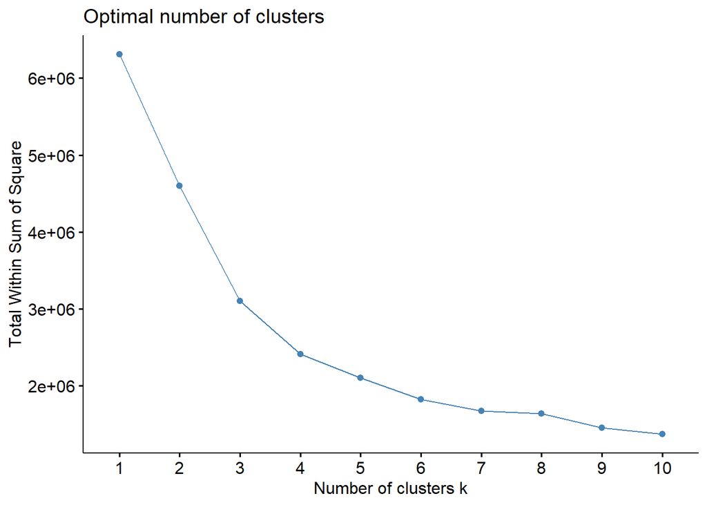

```r
pc.firstfour.unscaled = data.table(log.cancer.unscaled.centered %*% svd.cancer.unscaled$v[,1:4])
setnames(pc.firstfour.unscaled,c("PC1","PC2","PC3","PC4"))
fviz_nbclust(pc.firstfour.unscaled,kmeans,method = "wss")
```

We decide to choose $k=4$. On the one hand, The total WSS is no longer decreasing dramatically after $k=4$; on the other hand, this best conforms to our prior knowledge.

**Comparison between true groups and clusters**

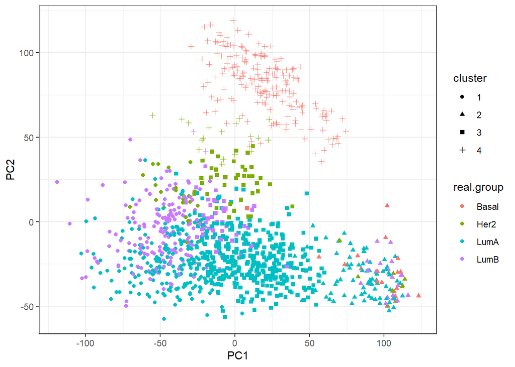

```r
set.seed(1)
kmeans.cancer.4pc = kmeans(pc.firstfour.unscaled,centers = 4)
cancer.groupcomp = data.table(log.cancer[,1],pc.firstfour.unscaled,cluster = as.factor(kmeans.cancer.4pc$cluster))
setnames(cancer.groupcomp,1,"real.group")

ggplot(data = cancer.groupcomp,aes(x=PC1,y=PC2,color=real.group,pch=cluster))+
  geom_point()+
  theme_bw()
```

Overall, the clustering result is not bad. Basal is identified more clearly; Her2 is almost unidentified at all. The clustering is not perfect but acceptable.

**Comparison of clustering with original data and PCs**

```r
# original
kbl(table(log.cancer$BRCA_Subtype_PAM50,kmeans.cancer$cluster), caption = "Discrepancy Table, Original", digits = 2, booktabs = T,align = "lcccc") %>%
  kable_styling(latex_options = c("HOLD_position"))
```

Discrepancy Table, Original

|  | 1 | 2 | 3 | 4 |
| --- | --- | --- | --- | --- |
| Basal | 0 | 17 | 1 | 190 |
| Her2 | 27 | 9 | 40 | 15 |
| LumA | 198 | 70 | 360 | 0 |
| LumB | 168 | 22 | 41 | 2 |

```r
# PC
kbl(table(log.cancer$BRCA_Subtype_PAM50,kmeans.cancer.4pc$cluster), caption = "Discrepancy Table, 4PC", digits = 2, booktabs = T,align = "lcccc") %>%
  kable_styling(latex_options = c("HOLD_position"))
```

Discrepancy Table, 4PC

|  | 1 | 2 | 3 | 4 |
| --- | --- | --- | --- | --- |
| Basal | 0 | 17 | 1 | 190 |
| Her2 | 24 | 9 | 40 | 18 |
| LumA | 205 | 73 | 350 | 0 |
| LumB | 165 | 22 | 44 | 2 |

Judging from the discrepancy tables, PCA seldom helps in kmeans clustering. In theory PCA just makes the information more intensive; if we are using all information with the original data in kmeans, its performance should not be much worse than that using only a few PCs with partial information. If it is the case that PCA does help, it may be attributed to the exclusion of noise.

**Classification of a new patient**

```r
patient[,(names(remove.col)) := NULL]

# deal with zeros
for (i in 1:ncol(patient)) {
  patient[get(colnames(patient)[i])==0,colnames(patient)[i] := min.positiveexp[i]/2, with = F]
}
save(patient,file = "patient.RData")
```

```r
load("patient.RData")
```

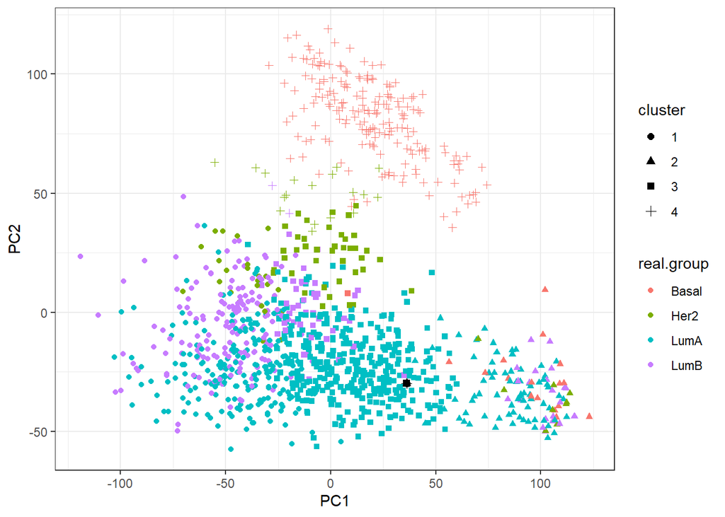

```r
# transforming
log.patient = log(patient)

# centering
log.patient = log.patient - apply(log.cancer[,-1],2,mean)

patient.firsttwo.unscaled = data.table(as.matrix(log.patient) %*% svd.cancer.scaled$v[,1:2])
patient.firsttwo.unscaled.mat = rbind(patient.firsttwo.unscaled,patient.firsttwo.unscaled,patient.firsttwo.unscaled,patient.firsttwo.unscaled)

ggplot(data = cancer.groupcomp,aes(x=PC1,y=PC2,color=real.group,pch=cluster))+
  geom_point()+
  geom_point(aes(x=patient.firsttwo.unscaled$V1,y=patient.firsttwo.unscaled$V2),color = "black",size=2)+
  theme_bw()
```

```r
distance = kmeans.cancer.4pc$centers[,1:2] - patient.firsttwo.unscaled.mat
distance.square = diag(as.matrix(distance) %*% t(as.matrix(distance)))

which.min(distance.square)
```

```
## [1] 3
```

# Case 3: Auto data set

## EDA, to be continued

**Summary Statistics**

```r
auto = data.table(Auto)
skim(auto)
```

Data summary

| Name | auto |
| --- | --- |
| Number of rows | 392 |
| Number of columns | 9 |
| Key | NULL |
| _______________________ |  |
| Column type frequency: |  |
| factor | 1 |
| numeric | 8 |
| ________________________ |  |
| Group variables | None |

**Variable type: factor**

| skim_variable | n_missing | complete_rate | ordered | n_unique | top_counts |
| --- | --- | --- | --- | --- | --- |
| name | 0 | 1 | FALSE | 301 | amc: 5, for: 5, toy: 5, amc: 4 |

**Variable type: numeric**

| skim_variable | n_missing | complete_rate | mean | sd | p0 | p25 | p50 | p75 | p100 | hist |
| --- | --- | --- | --- | --- | --- | --- | --- | --- | --- | --- |
| mpg | 0 | 1 | 23.45 | 7.81 | 9 | 17.0 | 22.8 | 29 | 46.6 | ▆▇▆▃▁ |
| cylinders | 0 | 1 | 5.47 | 1.71 | 3 | 4.0 | 4.0 | 8 | 8.0 | ▇▁▃▁▅ |
| displacement | 0 | 1 | 194.41 | 104.64 | 68 | 105.0 | 151.0 | 276 | 455.0 | ▇▂▂▃▁ |
| horsepower | 0 | 1 | 104.47 | 38.49 | 46 | 75.0 | 93.5 | 126 | 230.0 | ▆▇▃▁▁ |
| weight | 0 | 1 | 2977.58 | 849.40 | 1613 | 2225.2 | 2803.5 | 3615 | 5140.0 | ▇▇▅▅▂ |
| acceleration | 0 | 1 | 15.54 | 2.76 | 8 | 13.8 | 15.5 | 17 | 24.8 | ▁▆▇▂▁ |
| year | 0 | 1 | 75.98 | 3.68 | 70 | 73.0 | 76.0 | 79 | 82.0 | ▇▆▇▆▇ |
| origin | 0 | 1 | 1.58 | 0.81 | 1 | 1.0 | 1.0 | 2 | 3.0 | ▇▁▂▁▂ |

**Correlations**

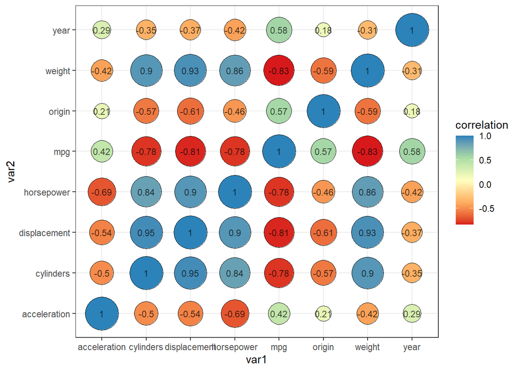

```r
auto.corr.mat = data.frame(round(cor(auto[,-"name"]), digits = 2),var1 = names(auto)[-ncol(auto)])
auto.corr.mat.long = data.table(melt(auto.corr.mat,id.vars = "var1", variable.name = "var2", value.name = "correlation"))
auto.corr.mat.long = auto.corr.mat.long[,var2 := as.character(var2)]
auto.corr.mat.long = auto.corr.mat.long[order(var1,var2)]

my_color = brewer.pal(5, "Spectral")
ggplot(data = auto.corr.mat.long,aes(x=var1,y=var2,fill = correlation))+
  geom_point(aes(size = abs(correlation)), shape = 21) +
  geom_text(aes(label = correlation), size = 3, colour = "black", alpha = 0.7)+
  scale_fill_gradientn(colours = my_color) +
  xlab("var1")+
  scale_size_area(max_size = 15, guide = "none") +
  theme_bw()
```

Some variables are highly correlated. Pay attention to collineaity problems.

**Pairwise scatter plots**

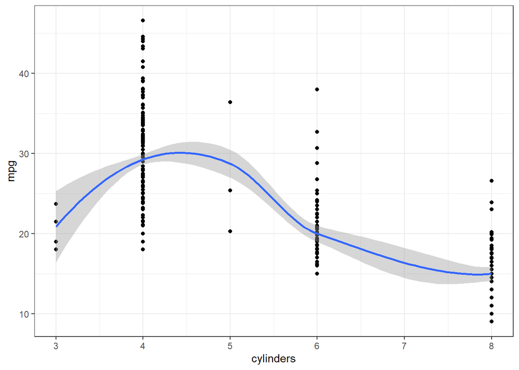

```r
ggplot(data = auto,aes(x=cylinders,y=mpg))+
  geom_point()+
  geom_smooth()+
  theme_bw()
```

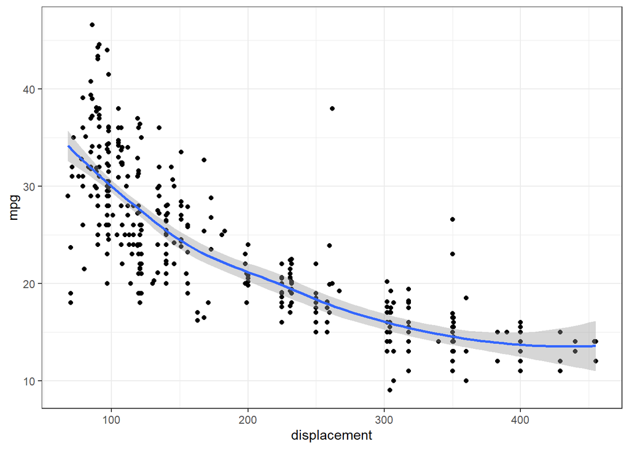

```r
ggplot(data = auto,aes(x=displacement,y=mpg))+
  geom_point()+
  geom_smooth()+
  theme_bw()
```

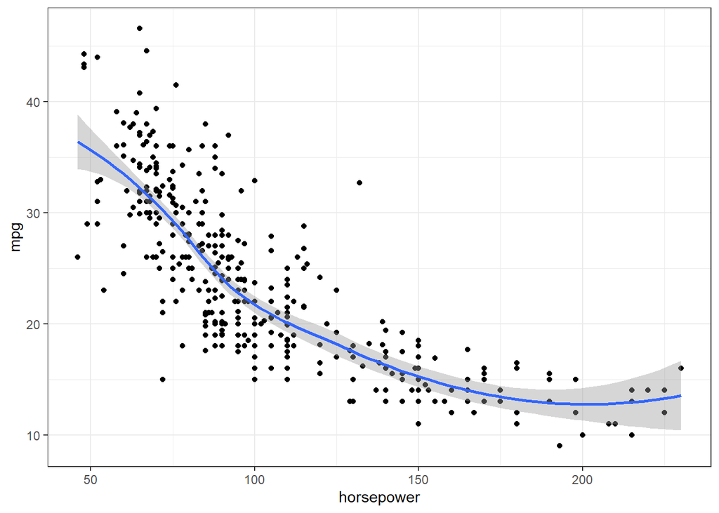

```r
ggplot(data = auto,aes(x=horsepower,y=mpg))+
  geom_point()+
  geom_smooth()+
  theme_bw()
```

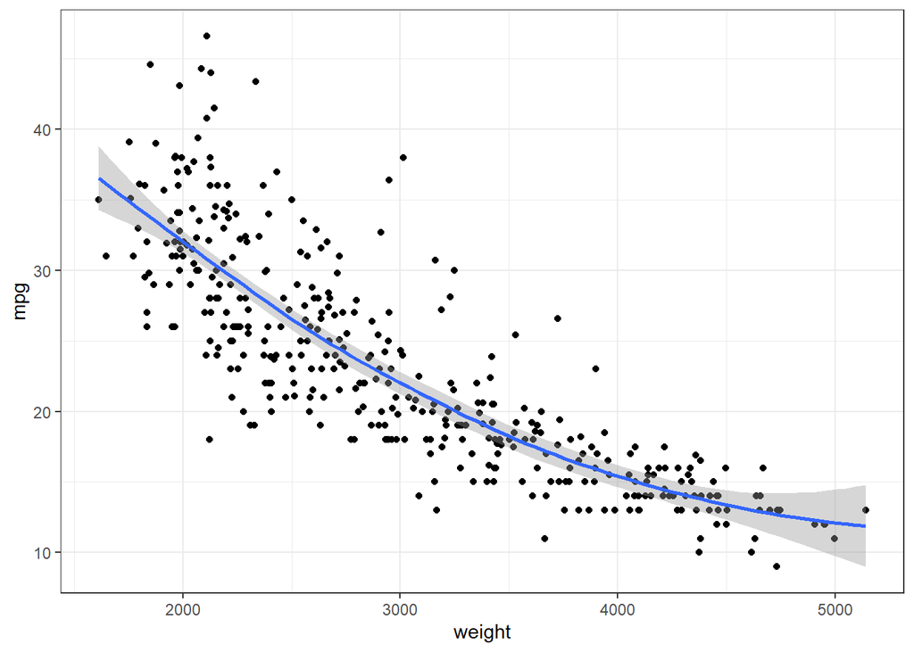

```r
ggplot(data = auto,aes(x=weight,y=mpg))+
  geom_point()+
  geom_smooth()+
  theme_bw()
```

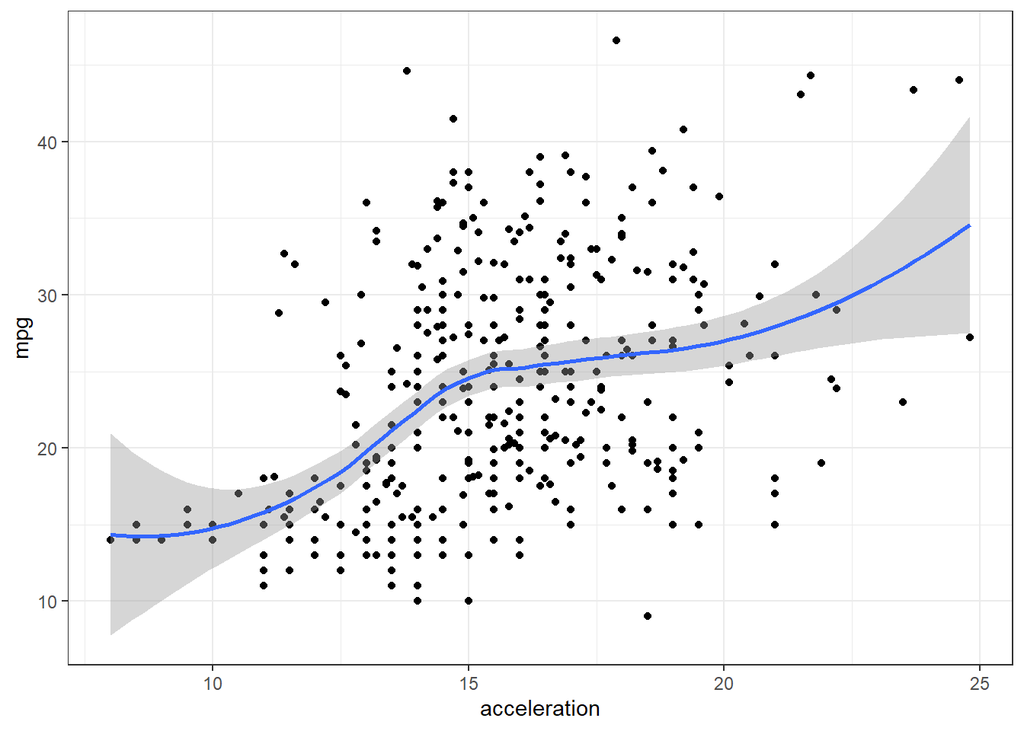

```r
ggplot(data = auto,aes(x=acceleration,y=mpg))+
  geom_point()+
  geom_smooth()+
  theme_bw()
```

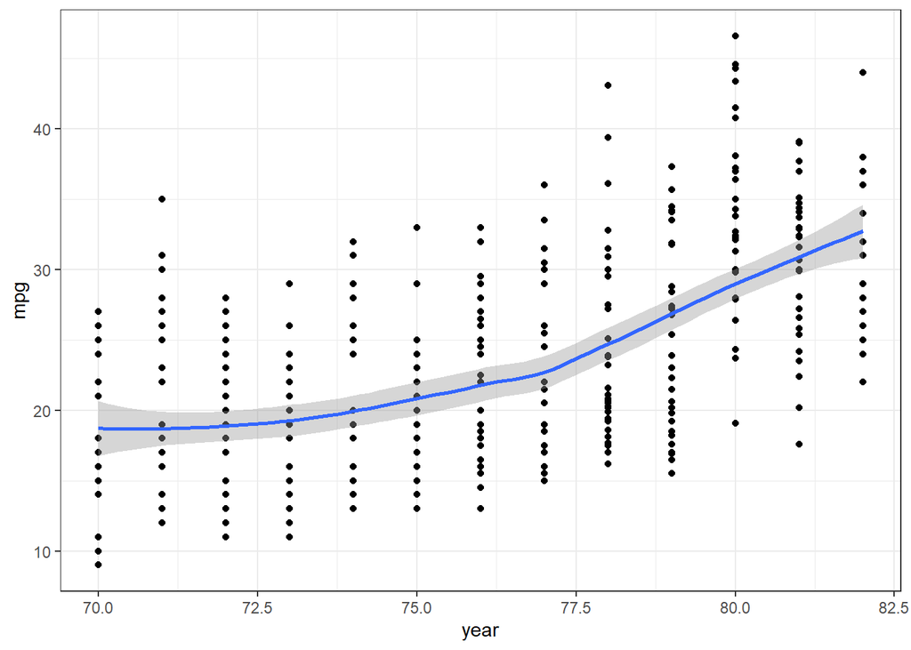

```r
ggplot(data = auto,aes(x=year,y=mpg))+
  geom_point()+
  geom_smooth()+
  theme_bw()
```

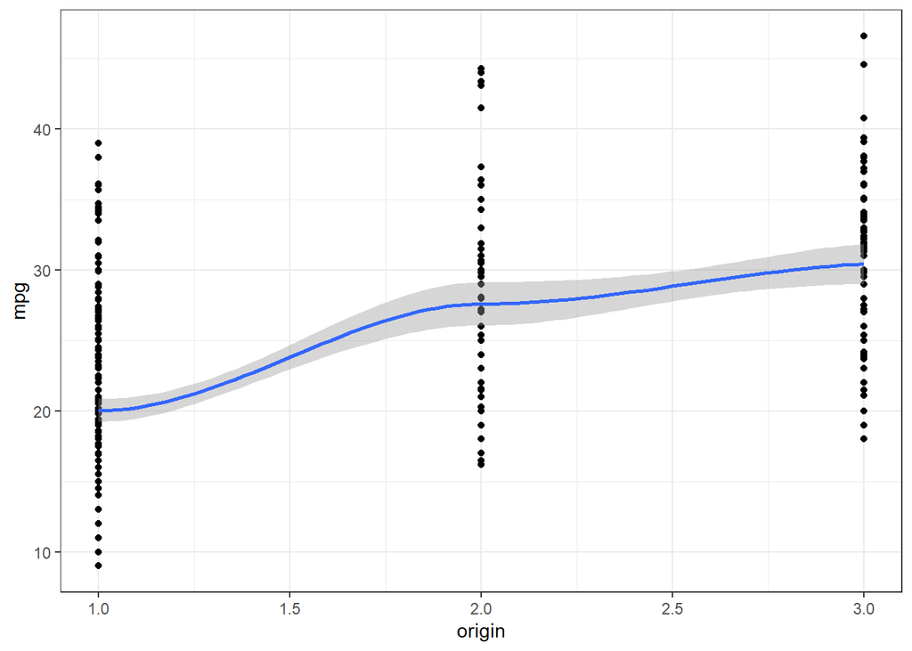

```r
ggplot(data = auto,aes(x=origin,y=mpg))+
  geom_point()+
  geom_smooth()+
  theme_bw()
```

## Year and mpg

```r
reg.year = lm(mpg~year,data = auto)
summary(reg.year)
```

```
##
## Call:
## lm(formula = mpg ~ year, data = auto)
##
## Residuals:
##     Min      1Q  Median      3Q     Max
## -12.021  -5.441  -0.441   4.974  18.209
##
## Coefficients:
##             Estimate Std. Error t value Pr(>|t|)
## (Intercept) -70.0117     6.6452   -10.5   <2e-16 ***
## year          1.2300     0.0874    14.1   <2e-16 ***
## ---
## Signif. codes:  0 '***' 0.001 '**' 0.01 '*' 0.05 '.' 0.1 ' ' 1
##
## Residual standard error: 6.36 on 390 degrees of freedom
## Multiple R-squared:  0.337,  Adjusted R-squared:  0.335
## F-statistic:  198 on 1 and 390 DF,  p-value: <2e-16
```

```r
reg.year.horse = lm(mpg~year+horsepower,data = auto)
summary(reg.year.horse)
```

```
##
## Call:
## lm(formula = mpg ~ year + horsepower, data = auto)
##
## Residuals:
##     Min      1Q  Median      3Q     Max
## -12.077  -3.078  -0.431   2.588  15.315
##
## Coefficients:
##              Estimate Std. Error t value Pr(>|t|)
## (Intercept) -12.73917    5.34903   -2.38    0.018 *
## year          0.65727    0.06626    9.92   <2e-16 ***
## horsepower   -0.13165    0.00634  -20.76   <2e-16 ***
## ---
## Signif. codes:  0 '***' 0.001 '**' 0.01 '*' 0.05 '.' 0.1 ' ' 1
##
## Residual standard error: 4.39 on 389 degrees of freedom
## Multiple R-squared:  0.685,  Adjusted R-squared:  0.684
## F-statistic:  424 on 2 and 389 DF,  p-value: <2e-16
```

```r
reg.year.horse.inter = lm(mpg~year+horsepower+year*horsepower,data = auto)
summary(reg.year.horse.inter)
```

```
##
## Call:
## lm(formula = mpg ~ year + horsepower + year * horsepower, data = auto)
##
## Residuals:
##     Min      1Q  Median      3Q     Max
## -12.349  -2.451  -0.456   2.406  14.444
##
## Coefficients:
##                  Estimate Std. Error t value Pr(>|t|)
## (Intercept)     -1.27e+02   1.21e+01  -10.45   <2e-16 ***
## year             2.19e+00   1.61e-01   13.59   <2e-16 ***
## horsepower       1.05e+00   1.15e-01    9.06   <2e-16 ***
## year:horsepower -1.60e-02   1.56e-03  -10.22   <2e-16 ***
## ---
## Signif. codes:  0 '***' 0.001 '**' 0.01 '*' 0.05 '.' 0.1 ' ' 1
##
## Residual standard error: 3.9 on 388 degrees of freedom
## Multiple R-squared:  0.752,  Adjusted R-squared:  0.75
## F-statistic:  393 on 3 and 388 DF,  p-value: <2e-16
```

## Categorical predictors

```r
reg.cyl.num = lm(mpg~cylinders,data = auto)
summary(reg.cyl.num)
```

```
##
## Call:
## lm(formula = mpg ~ cylinders, data = auto)
##
## Residuals:
##     Min      1Q  Median      3Q     Max
## -14.241  -3.183  -0.633   2.549  17.917
##
## Coefficients:
##             Estimate Std. Error t value Pr(>|t|)
## (Intercept)   42.916      0.835    51.4   <2e-16 ***
## cylinders     -3.558      0.146   -24.4   <2e-16 ***
## ---
## Signif. codes:  0 '***' 0.001 '**' 0.01 '*' 0.05 '.' 0.1 ' ' 1
##
## Residual standard error: 4.91 on 390 degrees of freedom
## Multiple R-squared:  0.605,  Adjusted R-squared:  0.604
## F-statistic:  597 on 1 and 390 DF,  p-value: <2e-16
```

```r
reg.cyl.fac = lm(mpg~as.factor(cylinders),data = auto)
stargazer(reg.cyl.fac,type = output_format,keep.stat = c("n", "rsq", "sigma2", "ser"))
```

[output not shown]